# Objective:

- Explore the dataset and extract insights using Exploratory Data Analysis .
- The overaching question is to help the business determine whether the new landing page is more effective than the old one . To answer that, we will look to answer these questions:
- 1.Do customers spend more time on the new landing page?
- 2.Is the conversion rate of the new landing page higher than old landing page?
- 3.Does the converted status depend on the prefered language?
- 4.Is the mean time spent on the new page same for the different language users?
- After we have the insights we can conclude whether the new landing page works

# Data:

**abtest.csv** - it contains information about customers purchasing product.

- user_id - This represents the user ID of the person visiting the website.
- group - This represents whether the user belongs to the first group (control) or the second group (treatment).
- landing_page - This represents whether the landing page is new or old.
- time_spent_on_the_page - This represents the time (in minutes) spent by the user on the landing page.
- converted - This represents whether the user gets converted to a subscriber of the news portal or not.
- language_preferred - This represents the language chosen by the user to view the landing page.

### Import the necessary packages

```python
import pandas as pd
import numpy as np
import seaborn as sns
import scipy.stats as stats
import statsmodels.stats.api as sms
import matplotlib.pyplot as plt
import warnings
warnings.filterwarnings('ignore')
%matplotlib inline
```

### Read the dataset

```python
data=pd.read_csv("abtest.csv")
```

```python
# copying data to another varaible to avoid any changes to original data
df=data.copy()
```

### View the first and last 5 rows of the dataset.

```python
df.head()
```

|  | user_id | group | landing_page | time_spent_on_the_page | converted | language_preferred |
| --- | --- | --- | --- | --- | --- | --- |
| 0 | 546592 | control | old | 3.48 | no | Spanish |
| 1 | 546468 | treatment | new | 7.13 | yes | English |
| 2 | 546462 | treatment | new | 4.40 | no | Spanish |
| 3 | 546567 | control | old | 3.02 | no | French |
| 4 | 546459 | treatment | new | 4.75 | yes | Spanish |

```python
df.tail()
```

|  | user_id | group | landing_page | time_spent_on_the_page | converted | language_preferred |
| --- | --- | --- | --- | --- | --- | --- |
| 95 | 546446 | treatment | new | 5.15 | no | Spanish |
| 96 | 546544 | control | old | 6.52 | yes | English |
| 97 | 546472 | treatment | new | 7.07 | yes | Spanish |
| 98 | 546481 | treatment | new | 6.20 | yes | Spanish |
| 99 | 546483 | treatment | new | 5.86 | yes | English |

### Understand the shape of the dataset.

```python
df.shape
```

```
(100, 6)
```

- The dataset contains 100 rows, and six columns

### Check the data types of the columns for the dataset.

```python
df.info()
```

```
<class 'pandas.core.frame.DataFrame'>
RangeIndex: 100 entries, 0 to 99
Data columns (total 6 columns):
 #   Column                  Non-Null Count  Dtype
---  ------                  --------------  -----
 0   user_id                 100 non-null    int64
 1   group                   100 non-null    object
 2   landing_page            100 non-null    object
 3   time_spent_on_the_page  100 non-null    float64
 4   converted               100 non-null    object
 5   language_preferred      100 non-null    object
dtypes: float64(1), int64(1), object(4)
memory usage: 3.2+ KB
```

#### convert the converted status into integer and add new column (converted1)

```python
df['converted1']=df['converted'].replace({'no': 0, 'yes': 1})
```

```python
df.converted.map(dict(yes=1, no=0))
```

```
0     0
1     1
2     0
3     0
4     1
     ..
95    0
96    1
97    1
98    1
99    1
Name: converted, Length: 100, dtype: int64
```

```python
df.head()
```

|  | user_id | group | landing_page | time_spent_on_the_page | converted | language_preferred | converted1 |
| --- | --- | --- | --- | --- | --- | --- | --- |
| 0 | 546592 | control | old | 3.48 | no | Spanish | 0 |
| 1 | 546468 | treatment | new | 7.13 | yes | English | 1 |
| 2 | 546462 | treatment | new | 4.40 | no | Spanish | 0 |
| 3 | 546567 | control | old | 3.02 | no | French | 0 |
| 4 | 546459 | treatment | new | 4.75 | yes | Spanish | 1 |

## Fixing the data types

- Group, landing page, converted and languaged prefered are of object types and we can change them to category

```python
df["group"]=df["group"].astype("category")
df["landing_page"]=df["landing_page"].astype("category")
df["converted"]=df["converted"].astype("category")
df["language_preferred"]=df["language_preferred"].astype("category")
```

### Check for missing values

```python
df.isnull().sum()
```

```
user_id                   0
group                     0
landing_page              0
time_spent_on_the_page    0
converted                 0
language_preferred        0
converted1                0
dtype: int64
```

- there is no missing data from the dataset

```python
df.info()
```

```
<class 'pandas.core.frame.DataFrame'>
RangeIndex: 100 entries, 0 to 99
Data columns (total 7 columns):
 #   Column                  Non-Null Count  Dtype
---  ------                  --------------  -----
 0   user_id                 100 non-null    int64
 1   group                   100 non-null    category
 2   landing_page            100 non-null    category
 3   time_spent_on_the_page  100 non-null    float64
 4   converted               100 non-null    category
 5   language_preferred      100 non-null    category
 6   converted1              100 non-null    int64
dtypes: category(4), float64(1), int64(2)
memory usage: 3.1 KB
```

- group, landing_page, converted and language_prefered have been converted to categories

### Give a statistical summary for the dataset.

```python
df.describe()
```

|  | user_id | time_spent_on_the_page | converted1 |
| --- | --- | --- | --- |
| count | 100.000000 | 100.000000 | 100.000000 |
| mean | 546517.000000 | 5.377800 | 0.540000 |
| std | 52.295779 | 2.378166 | 0.500908 |
| min | 546443.000000 | 0.190000 | 0.000000 |
| 25% | 546467.750000 | 3.880000 | 0.000000 |
| 50% | 546492.500000 | 5.415000 | 1.000000 |
| 75% | 546567.250000 | 7.022500 | 1.000000 |
| max | 546592.000000 | 10.710000 | 1.000000 |

- Mean of time spent on the page is slightly smaller than the median, this suggests that mean of time spent is slightly left skewed but not much.
- On average users spend 5.4 minutes on the landing page
- User id is just the id used to identify user so there's no need to analyze here

```python
df.describe(include=["category"])
```

|  | group | landing_page | converted | language_preferred |
| --- | --- | --- | --- | --- |
| count | 100 | 100 | 100 | 100 |
| unique | 2 | 2 | 2 | 3 |
| top | control | new | yes | French |
| freq | 50 | 50 | 54 | 34 |

### 1. Univariate analysis

```python
# While doing uni-variate analysis of numerical variables we want to study their central tendency
# and dispersion.
# Let us write a function that will help us create boxplot and histogram for any input numerical
# variable.
# This function takes the numerical column as the input and returns the boxplots
# and histograms for the variable.
# Let us see if this help us write faster and cleaner code.
def histogram_boxplot(feature, figsize=(15,10), bins = None):
    """ Boxplot and histogram combined
    feature: 1-d feature array
    figsize: size of fig (default (9,8))
    bins: number of bins (default None / auto)
    """
    f2, (ax_box2, ax_hist2) = plt.subplots(nrows = 2, # Number of rows of the subplot grid= 2
                                           sharex = True, # x-axis will be shared among all subplots
                                           gridspec_kw = {"height_ratios": (.25, .75)},
                                           figsize = figsize
                                           ) # creating the 2 subplots
    sns.boxplot(feature, ax=ax_box2, showmeans=True, color='violet') # boxplot will be created and a star will indicate the mean value of the column
    sns.distplot(feature, kde=F, ax=ax_hist2, bins=bins,palette="winter") if bins else sns.distplot(feature, kde=False, ax=ax_hist2) # For histogram
    ax_hist2.axvline(np.mean(feature), color='green', linestyle='--') # Add mean to the histogram
    ax_hist2.axvline(np.median(feature), color='black', linestyle='-') # Add median to the histogram
```

## Observations on time_spent_on_the_page

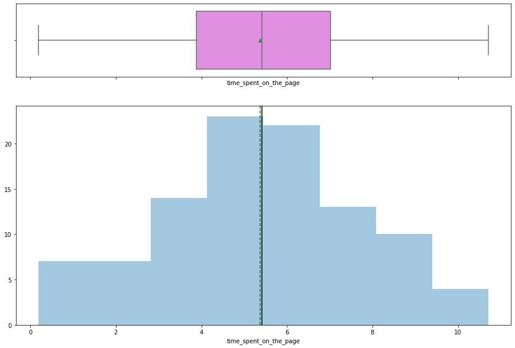

```python
histogram_boxplot(df["time_spent_on_the_page"])
```

- The distribution of time_spent_on_the_page is fairly normal
- There is no outliers in this variable.

#### Create user def function for the plot

```python
# Function to create barplots that indicate percentage for each category.

def perc_on_bar(plot, feature):
    '''
    plot
    feature: categorical feature
    the function won't work if a column is passed in hue parameter
    '''
    total = len(feature) # length of the column
    for p in ax.patches:
        percentage = '{:.1f}%'.format(100 * p.get_height()/total) # percentage of each class of the category
        x = p.get_x() + p.get_width() / 2 - 0.05 # width of the plot
        y = p.get_y() + p.get_height()           # hieght of the plot
        ax.annotate(percentage, (x, y), size = 12) # annotate the percantage
    plt.show() # show the plot
```

## Observations on Language_preferred

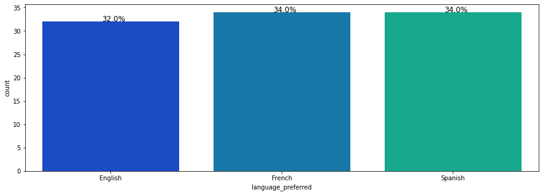

```python
plt.figure(figsize=(15,5))
ax = sns.countplot(df["language_preferred"],palette='winter')
perc_on_bar(ax,df["language_preferred"])
```

- Spanish and French are used more than English

## Observations on converted

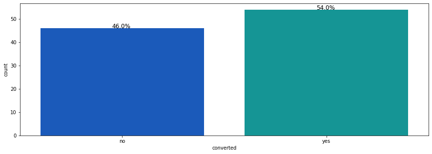

```python
plt.figure(figsize=(15,5))
ax = sns.countplot(df["converted"],palette='winter')
perc_on_bar(ax,df["converted"])
```

- There are 54% total users being converted and 46% not converted

### 2. Bivariate Analysis

### time_spent vs converted

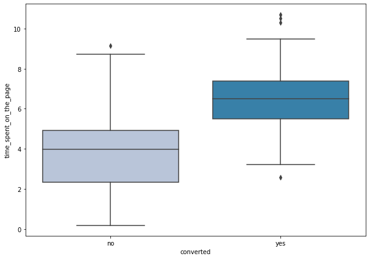

```python
plt.figure(figsize=(10,7))
sns.boxplot(df['converted'],df['time_spent_on_the_page'], palette="PuBu")
plt.show()
```

- From this chart we can see that for group of converted users, on average they spend more time on the page than group no-converted. The average time on the page of converted users is ~6.3mins, while average time on non-converted user is ~4mins

### time_spent vs language_preferred

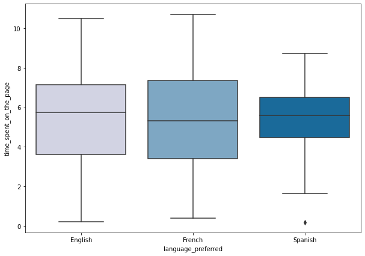

```python
plt.figure(figsize=(10,7))
sns.boxplot(df['language_preferred'],df['time_spent_on_the_page'], palette="PuBu")
plt.show()
```

- Generally average users who use French spend less time on the page than English and Spanish

### languaged_prefered vs converted

```python
plt.figure(figsize=(10,7))
sns.countplot(df["language_preferred"],hue=df["converted"],palette='winter')
plt.legend(bbox_to_anchor=(1.00, 1))
plt.show()
```

[output not shown]

- We can see English user has higher number of converted users than other languagues. French has lowest number of converted users and highest number of non-converted users.

### landing page vs converted

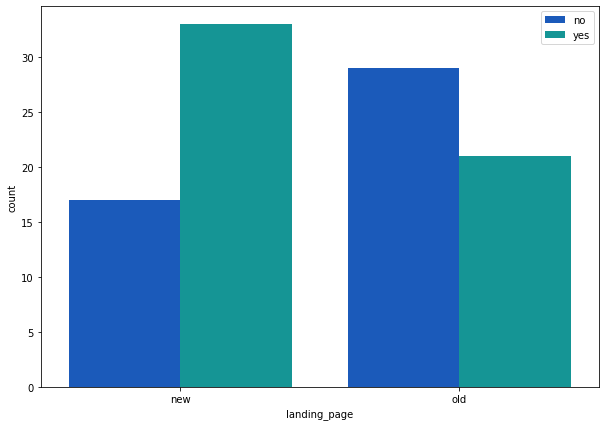

```python
plt.figure(figsize=(10,7))
sns.countplot(df["landing_page"],hue=df["converted"],palette='winter')
plt.legend(bbox_to_anchor=(1.00, 1))
plt.show()
```

- New landing page has much higher conversion ratio than old landing page

### converted vs language_preferred

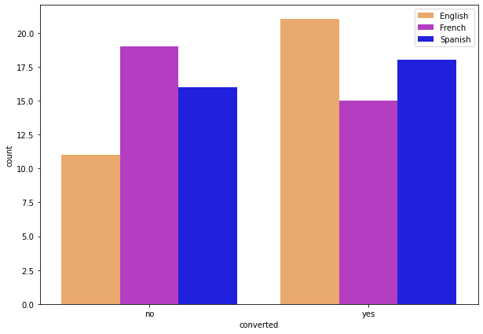

```python
plt.figure(figsize=(10,7))
sns.countplot(df["converted"],hue=df["language_preferred"],palette='gnuplot2_r')
plt.legend(bbox_to_anchor=(1.00, 1))
plt.show()
```

- Of the converted group, English is used the most, next is Spanish and French. Of the non-converted group, French is used the most, next are Spanish and English. This means that English seems to be a best language option to convert users, while French should not be used.

### landing_page vs time_spent

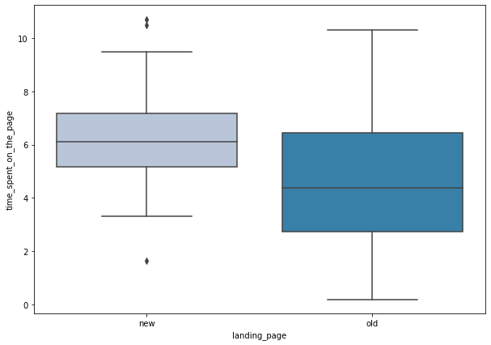

```python
plt.figure(figsize=(10,7))
sns.boxplot(df['landing_page'],df['time_spent_on_the_page'], palette="PuBu")
plt.show()
```

### Landing page vs converted vs language

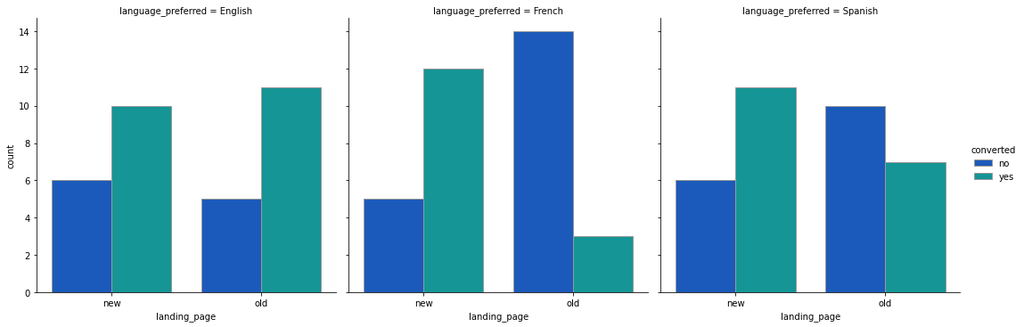

```python
ax=sns.catplot(x='landing_page', hue='converted', col='language_preferred',palette='winter', edgecolor='.6', kind='count', data=df)
plt.show()
```

- For language= French : new landing page has much higher conversion ratio than old landing page
- For language= English: new landing page has slightly lower conversion ratio than old landing page
- For language= Spanish: new landing page help converts users much better than old landing page

## HYPOTHESIS TESTING TO ANSWER KEY QUESTIONS

### Prepare the data: Grouping data into 2 subdataset for easy reference

```python
#name this dataset as "control"
control=df[df["group"]=="control"]
```

```python
control.head()
```

|  | user_id | group | landing_page | time_spent_on_the_page | converted | language_preferred | converted1 |
| --- | --- | --- | --- | --- | --- | --- | --- |
| 0 | 546592 | control | old | 3.48 | no | Spanish | 0 |
| 3 | 546567 | control | old | 3.02 | no | French | 0 |
| 5 | 546558 | control | old | 5.28 | yes | English | 1 |
| 7 | 546581 | control | old | 6.53 | yes | Spanish | 1 |
| 9 | 546548 | control | old | 2.08 | no | English | 0 |

```python
control.describe()
```

|  | user_id | time_spent_on_the_page | converted1 |
| --- | --- | --- | --- |
| count | 50.00000 | 50.000000 | 50.000000 |
| mean | 546566.50000 | 4.532400 | 0.420000 |
| std | 17.67767 | 2.581975 | 0.498569 |
| min | 546493.00000 | 0.190000 | 0.000000 |
| 25% | 546555.25000 | 2.720000 | 0.000000 |
| 50% | 546567.50000 | 4.380000 | 0.000000 |
| 75% | 546579.75000 | 6.442500 | 1.000000 |
| max | 546592.00000 | 10.300000 | 1.000000 |

##### Group "Control" - insights

- Average time spent with OLD landing page is 4.5 min (maximum time is 10.3 mins)
- Most prefered language is French
- Proportion of no-conversion is higher (29 / 50 or 58%) , in other words conversion rate is 42%)for this group
- Standard deviation of time_spent is 2.6 mins

```python
#group 2: treatment
treatment=df[df["group"]=="treatment"]
```

```python
treatment.head()
```

|  | user_id | group | landing_page | time_spent_on_the_page | converted | language_preferred | converted1 |
| --- | --- | --- | --- | --- | --- | --- | --- |
| 1 | 546468 | treatment | new | 7.13 | yes | English | 1 |
| 2 | 546462 | treatment | new | 4.40 | no | Spanish | 0 |
| 4 | 546459 | treatment | new | 4.75 | yes | Spanish | 1 |
| 6 | 546448 | treatment | new | 5.25 | yes | French | 1 |
| 8 | 546461 | treatment | new | 10.71 | yes | French | 1 |

```python
treatment.describe()
```

|  | user_id | time_spent_on_the_page | converted1 |
| --- | --- | --- | --- |
| count | 50.00000 | 50.000000 | 50.000000 |
| mean | 546467.50000 | 6.223200 | 0.660000 |
| std | 14.57738 | 1.817031 | 0.478518 |
| min | 546443.00000 | 1.650000 | 0.000000 |
| 25% | 546455.25000 | 5.175000 | 0.000000 |
| 50% | 546467.50000 | 6.105000 | 1.000000 |
| 75% | 546479.75000 | 7.160000 | 1.000000 |
| max | 546492.00000 | 10.710000 | 1.000000 |

#### Group "Treatment" insights

- Average time spent with NEW landing page is 6.2 min - which is higher than control group (old landing page) (and maximum time is 10.7 mins)
- Most prefered language is the same- French
- There are 33 out of 50 people who are converted - in other words conversion rate of this group is 66%
- Standard deviation of time_spent is 1.8 mins

```python
#name this dataset as "treatment"
treatment=df[df["group"]=="treatment"].describe(include="all")
```

### Q1 - Do customers spend more time on the new landing page?

### Visualisation: time spent on new and old landing page

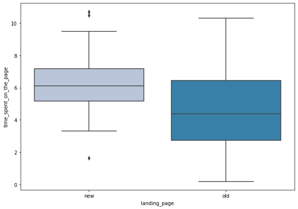

```python
plt.figure(figsize=(10,7))
sns.boxplot(df['landing_page'],df['time_spent_on_the_page'], palette="PuBu")
plt.show()
```

### Step 1: Define null and alternate hypotheses

$H_0:$ mean of time spent on the control group is equal to that of treatment group

$H_a:$ mean of time spent on the control group is smaller than that of treatment group

Let $\mu_1, \mu_2$ be the mean of time_spent_on_the_page of control group and treatment group respectively.

We will test the null hypothesis

> $H_0:\mu_1=\mu_2$

against the alternate hypothesis

> $H_a:\mu_1<\mu_2$

### Step 2: Select Appropriate test

For the problem, we have to compare the sample means from 2 independent population when standard deviation are unknown. Therefore we will use 2-sample independent t-test here

#### Let's test whether the T-test assumptions are satisfied or not

  We can use 2 sample T-test for this problem: testing the equality of sample means of 2 samples

### Step 3: Decide significance level

For this test we select α = 0.05.

### Step 4: Collect & prepare data

```python
#import required function
from scipy.stats import ttest_ind
#prepare the data
control_time = df[df['landing_page'] == 'old']['time_spent_on_the_page']
treatment_time = df[df['landing_page'] == 'new']['time_spent_on_the_page']
```

### Step 5: Find p-value

```python
#find p-value
test_stat, p_value = ttest_ind(control_time, treatment_time, equal_var = True, alternative = 'less')
print('The p-value is ', p_value)
```

```
The p-value is  0.0001316123528095005
```

### Insight

As the p-value (~0.0001) is less than the level of significance (0.05), we can reject the null hypothesis. Thus, it may be concluded that there is enough statistical evidence to conclude that the time spent on the new landing page (treatment group) is higher than old landing page (control group)

### Q2- Is the conversion rate of the new landing page higher than old landing page?

#### Calculate the conversion rate by group

```python
conversion_rates = df.groupby('group')['converted1']

std_p = lambda x: np.std(x, ddof=0)              # Std. deviation of the proportion
se_p = lambda x: stats.sem(x, ddof=0)            # Std. error of the proportion (std / sqrt(n))

conversion_rates = conversion_rates.agg([np.mean, std_p, se_p])
conversion_rates.columns = ['conversion_rate', 'std_deviation', 'std_error']


conversion_rates.style.format('{:.3f}')
```

| group | conversion_rate | std_deviation | std_error |
| --- | --- | --- | --- |
| control | 0.420 | 0.494 | 0.070 |
| treatment | 0.660 | 0.474 | 0.067 |

- From the above analysis, we can have the Hypothesis that that Conversion rate of new landing page is HIGHER than old landing page.
- We will use 2 Proportion Z-test for this question
- We will use the 5% significance level for this test

### Step 1: Define null and alternate hypotheses

$H_0:$ conversion rate of control group is equal to that of treatment group

$H_a:$ conversion rate of control group is smaller than that of treatment group

Let $p_1,p_2$ be the proportions of conversion (conversion ratio) in control group and treatment group respectively.

We will test the null hypothesis

> $H_0:p_1 =p_2$

against the alternate hypothesis

> $H_a:p_1 < p_2$

### Step 2: Select appropriate test

With this problem, we need to compare the proportion (conversion rate) of two populations (control and treatment group) and conclude if conversion rate of new landing page is higher than old landing page Therefore we will use the 2 sample 1 tailed Z-test (proportion)

### Let's test whether the Z-test assumptions are satisfied or not

- Binomally distributed population - Yes, a conversion option is either CONVERTED or NOT CONVERTED
- Random sampling from the population - Yes, we are informed that the collected sample is a simple random sample.
- Can the binomial distribution approximated to normal distribution - Yes.

### Step 3: Decide the significance level

We select α = 0.05.

### Step 4: Collect & prepare data

From the above tables, we know that the number of converted users in control group is 21 (50-29) We also know the number of converted users in treatment group is 33

```python
# import the required fuction
from statsmodels.stats.proportion import proportions_ztest

# set the counts of converted user
count = np.array([21, 33])

# set the sample sizes
nobs = np.array([50, 50])
```

### Step 5: Calculate the p-value

```python
# find the p-value
test_stat, p_value= proportions_ztest(count,nobs,alternative='smaller')
print('The p-value is ' +str(p_value))
```

```
The p-value is 0.008026308204056278
```

### Step 6: compare p-value with 𝛼

```python
# print the conclusion based on p-value
if p_value < 0.05:
    print(f'As the p-value {p_value} is less than the level of significance, we reject the null hypothesis.')
else:
    print(f'As the p-value {p_value} is greater than the level of significance, we fail to reject the null hypothesis.')
```

```
As the p-value 0.008026308204056278 is less than the level of significance, we reject the null hypothesis.
```

### Step 7: Draw inference

As the p-value (0.008) is smaller than the significance level 0.05, we can reject Ho and conclude that we have enough statistical evidence to support that conversion rate of new landing page is higher than old landing page

### Q3- Does the converted status depend on the prefered language?

### Visualisation

```python
plt.figure(figsize=(10,7))
sns.countplot(df["language_preferred"],hue=df["converted"],palette='winter')
plt.legend(bbox_to_anchor=(1.00, 1))
plt.show()
```

[output not shown]

The hypothesis we want to test is the converted status depends on the language preferred on the site

### Step 1: Define null and alternative hypotheses

$H_0:$ conversion rate does not depends on the preferred language

$H_a:$ conversion rate depends on the preferred language

We will test the null hypothesis

> $H_0:$ converted status does not depend on prefered language

against the alternate hypothesis

> $H_a:$ converted status depends on prefered language

### Step 2: Select Appropriate test

With the question above, basically we want to check whether categorical variables (converted status (yes/no)) from a population (language user) are independent.

Hence, we can use Chi-Square Test for independence

#### Let's test whether assumptions are satisfied or not

- Categorical variable: yes
- expected value of the number of sample observations in each level of the variable is at least 5: yes
- Random sampling from the population: yes, we know that the sample is randomly collected Hence we can use Chi-Square Test for independence

### Step 3: Decide significance level

For this test we select α = 0.05.

### Step 4: Collect & Prepare Data

```python
#import the required function
from scipy.stats import chi2_contingency

#preparing the contingency table
cont_table=pd.crosstab(df['converted'], df['language_preferred'])
```

```python
cont_table.head()
```

| language_preferred converted | English | French | Spanish |
| --- | --- | --- | --- |
| no | 11 | 19 | 16 |
| yes | 21 | 15 | 18 |

### Step 5: Find the p-value

```python
chi, p_value, dof, expected= chi2_contingency(cont_table)
print('The p-value is', p_value)
```

```
The p-value is 0.21298887487543447
```

### Step 6: compare p-value with 𝛼

```python
# print the conclusion based on p-value
if p_value < 0.05:
    print(f'As the p-value {p_value} is less than the level of significance, we reject the null hypothesis.')
else:
    print(f'As the p-value {p_value} is greater than the level of significance, we fail to reject the null hypothesis.')
```

```
As the p-value 0.21298887487543447 is greater than the level of significance, we fail to reject the null hypothesis.
```

### Step 7: Draw inference

As the p-value (0.21) is higher than the significance level, we fail to reject the null hypothesis. This mean we do not have enough statistical evidence to conclude that converted status depends on the preferred language at 5% significance level.

### Q4- Is mean time spent on the new page the same for different language users?

### Visualisation

```python
plt.figure(figsize=(10,7))
sns.countplot(df["language_preferred"],hue=df["converted"],palette='winter')
plt.legend(bbox_to_anchor=(1.00, 1))
plt.show()
```

[output not shown]

### Step 1: Define null and alternative hypotheses

$H_0:$ mean of time spent of different group users are the same

$H_a:$ At least mean of time spent of one group user is different from the rest

Let $\mu_1, \mu_2, \mu_3$ be the mean of time_spent on the NEW page of group English, Spanish and French users We will test the null hypothesis

> $H_0: \mu_1 = \mu_2 = \mu_3$

against the alternative hypothesis

> $H_a: $ At least mean of time spent on the NEW page of one language group user is different from the rest

We look at the data of treatment group again

```python
treatment.head()
```

|  | user_id | group | landing_page | time_spent_on_the_page | converted | language_preferred | converted1 |
| --- | --- | --- | --- | --- | --- | --- | --- |
| count | 50.0 | 50 | 50 | 50.0000 | 50 | 50 | 50.00 |
| unique | NaN | 1 | 1 | NaN | 2 | 3 | NaN |
| top | NaN | treatment | new | NaN | yes | French | NaN |
| freq | NaN | 50 | 50 | NaN | 33 | 17 | NaN |
| mean | 546467.5 | NaN | NaN | 6.2232 | NaN | NaN | 0.66 |

```python
# mean of time_spent of different language users (on new page)
print(treatment.groupby("language_preferred")["time_spent_on_the_page"].mean())
```

```
language_preferred
3          NaN
17         NaN
50        50.0
French     NaN
Name: time_spent_on_the_page, dtype: float64
```

[figure not shown]

```python
# draw the boxplot for visualization
fig, ax = plt.subplots(figsize = (6,6))
a = sns.boxplot(x= "language_preferred", y = 'time_spent_on_the_page' , data = treatment, hue = 'language_preferred')
a.set_title("Language prefered vs time spent", fontsize=10)
plt.show()
```

### Step 2: Select Appropriate test

This is a problem concerning 3 population means, One - way Anova could be the appropriate test here provided the normality

Now, the normality and equality of variance assumptions need to be checked.

- Assumption 1: For testing of normality, Shapiro-Wilk’s test is used
- Assumption 2: for testing of equality of variance, Levene test is used

### Shapiro-Wilk’s test

We will test the null hypothesis

𝐻0: time spent follows a normal distribution against

against the alternative hypothesis

𝐻𝑎: time spent n does not follow a normal distribution We will use the significance level of 0.05

```python
#Assumption 1: Normal distribution
from scipy import stats

# find the p-value
w, p_value = stats.shapiro(treatment['time_spent_on_the_page'])
print('The p-value is', p_value)
```

```
The p-value is 1.0
```

### Levene’s test

We will test the null hypothesis

> $H_0$: All the population variances are equal

against the alternative hypothesis

> $H_a$: At least one variance is different from the rest We will use the significance level of 0.05

```python
#Assumption 2: Homogeneity of Variance
#import the required function
from scipy.stats import levene
statistic, p_value = levene( treatment['time_spent_on_the_page'][treatment['language_preferred']=="English"],
                                   treatment['time_spent_on_the_page'][treatment['language_preferred']=="French"],
                                   treatment['time_spent_on_the_page'][treatment['language_preferred']=="Spanish"])
# find the p-value
print('The p-value is', p_value)
```

```
The p-value is nan
```

### Step 3: Decide significance level

For this test we select α = 0.05.

### Step 4: Collect & prepare data

```python
#import the required function
from scipy.stats import f_oneway

#preparing the data: remember we already created a subdataset as 'treatment' which contain all data of users using new landing page

english1=df.loc[(df['landing_page']=='new') & (df['language_preferred']=='English'),'time_spent_on_the_page']
spanish1=df.loc[(df['landing_page']=='new') & (df['language_preferred']=='Spanish'),'time_spent_on_the_page']
french1=df.loc[(df['landing_page']=='new') & (df['language_preferred']=='French'),'time_spent_on_the_page']
```

### Step 5: Find p-value

```python
# perform one-way anova test using f_oneway function
# find the p-value
test_stat, p_value=f_oneway(english1,spanish1,french1)
print('The p_value is ', p_value)
```

```
The p_value is  0.43204138694325955
```

### Step 6: compare p-value with 𝛼

```python
# print the conclusion based on p-value
if p_value < 0.05:
    print(f'As the p-value {p_value} is less than the level of significance, we reject the null hypothesis.')
else:
    print(f'As the p-value {p_value} is greater than the level of significance, we fail to reject the null hypothesis.')
```

```
As the p-value 0.43204138694325955 is greater than the level of significance, we fail to reject the null hypothesis.
```

### Step 7: Draw inference

As the p-value is larger than the level of significance 0.05, we fail to reject the null Hypothesis. Thus, we do not have enough statistical evidence to say that mean of time spent of different language users are different

### -------------------------------------------THE END-------------------------------------------